# Model 6 filtering results

```r
library(foreach)
library(iterators)
library(plyr)
library(tidyr)
library(dplyr)
library(ggplot2)
library(ggpubr)
library(doParallel)
registerDoParallel(cores= 6)
library(doRNG)
registerDoRNG(625904618)
library(pomp)
```

In this notebook I examine Model 6, which is SIR with maternal immunity given by both recovered and latent states. There is a seasonal birth pulse and we fit a seasonal drive for I -> R transitions.

We are not fitting population dynamics parameters except for the birth pulse. The params we are not fitting are at Aarons posterior estimates, and kappa = 5000 as fro the Clunes site estimates of bats are around 4000-6000. For the other params, we start the fitting with intiial values given by 5 repeats of Aaron’s posterior values and 25 point from a Sobol grid of his 95% CI"

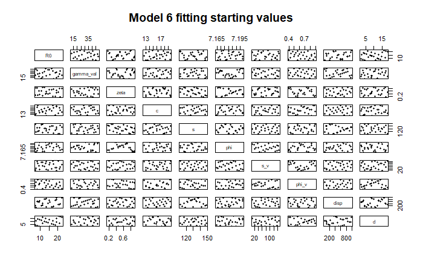

```r
pairs(~R0+gamma_val+zeta+c+s+phi+s_v+phi_v+disp+d, data = guesses, pch = 20, main = "Model 6 fitting starting values")
```

```
Using 2500 particels and 50 iterations with iterated filtering, we got the following results for iterated filtering:
```

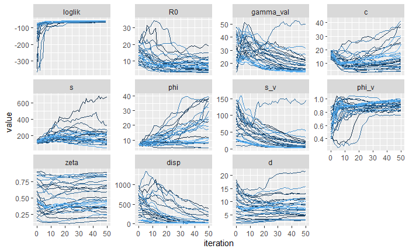

```r
mf3iter2 %>%
  traces() %>%
  melt() %>%
  filter(variable %in% c("loglik", "R0", "gamma_val",  "zeta", "c",
                         "s", "phi","s_v", "phi_v", "disp", "d") )%>%
  ggplot(aes(x=iteration,y=value,group=L1,color=L1))+
  geom_line()+
  facet_wrap(~variable,scales="free_y")+
  guides(color=FALSE) -> pl1

plot(pl1)
```

Here we see that the loglikelihood went up quickly after the first few iterations, and then stayed at around the same level. The seasonal dive params converged slightly, while other values don’t show a clear convergence.

The top values are the following, the best 5 have loglik around -57. We can indeed see that we have a large range for the end parameters with the same loglikelihood.

```r
head(model6_likelihoods, 5) %>%
  select (c("loglik", "loglik.se", "R0", "gamma_val",  "zeta", "c",
                         "s", "phi","s_v", "phi_v", "disp", "d"))
```

|  | loglik | loglik.se | R0 | gamma_val | zeta | c | s | phi | s_v | phi_v | disp | d |
| --- | --- | --- | --- | --- | --- | --- | --- | --- | --- | --- | --- | --- |
| 1 | -57.08639 | 0.012057551 | 5.225248 | 14.20830 | 0.3528729 | 25.14881 | 217.68170 | 11.904627 | 3.815666 | 0.9410068 | 31.59806 | 8.973369 |
| 2 | -57.15734 | 0.005642229 | 5.606161 | 13.13055 | 0.4154762 | 30.31144 | 219.19077 | 8.433648 | 2.925768 | 0.9692760 | 24.25605 | 7.397226 |
| 3 | -57.21503 | 0.006752608 | 5.181754 | 14.18756 | 0.4533374 | 14.39019 | 50.57135 | 24.306602 | 3.244465 | 0.9652978 | 28.47899 | 7.224995 |
| 4 | -57.24702 | 0.006422332 | 3.023563 | 14.58427 | 0.3263665 | 28.76022 | 132.22595 | 8.407105 | 5.430009 | 0.9032692 | 24.04671 | 6.812972 |
| 5 | -57.31030 | 0.007137996 | 8.622686 | 13.48223 | 0.3985311 | 14.99538 | 123.91510 | 11.447325 | 2.594693 | 0.9798887 | 27.09269 | 10.415279 |

Now we can visualise differently where our parameters converged to. The grey points are the starting values (same as on the first plot), and the red point are the results of the filtering.

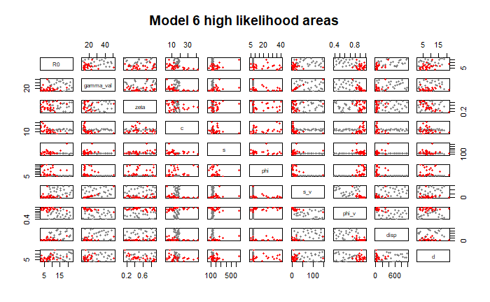

```r
  all <- ldply(list(guess=guesses,result=subset(model6_likelihoods,loglik>max(loglik)-20)))
pairs(~R0+gamma_val+zeta+
        c+s+phi+s_v+phi_v+disp+d,data=all,col=ifelse(all$.id=="guess",grey(0.5),"red"),pch=20,main ="Model 6 high likelihood areas" )
```

Here we can see that the points converged to smaller areas than we started with, like at R0.

On this plot, we look independently at the likelihoods of the resulting parameter values, to see the range that gave the same likelihoods:

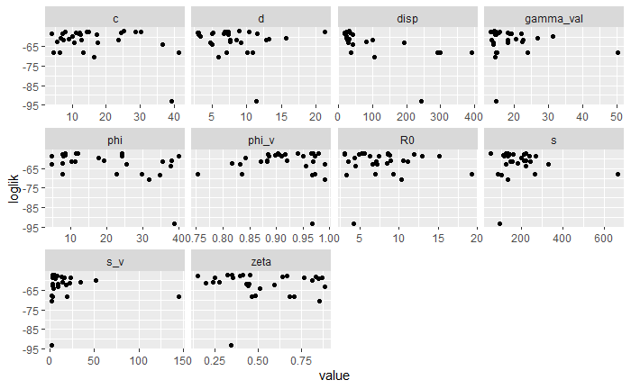

```r
gather(model6_likelihoods, key, value, -loglik) %>%
  filter(key %in% c( "R0", "gamma_val",  "zeta", "c",
                              "s", "phi","s_v", "phi_v", "disp", "d")) %>%
ggplot(aes(value, loglik), main = "Results of model 6 IF") +
   geom_point() +
  facet_wrap(~ key , scales="free_x", ncol=4) -> pl4

plot(pl4)
```

[output not shown]

```r
source("./../../pomp_model_fn.R")
source("./../../aarons_params.R")

head(model6_likelihoods, 5) %>%
  select( -c("loglik","loglik.se")) -> best_params
apply(best_params, 1, function(x)
  pomp_model_fn(site="CLU", year="all",
                init_states= model_4_before_equ_ini,
                input_params = x)) -> best_params_plots
```

```
The working directory was changed to C:/Users/alexa/OneDrive/Documents/BatsProject/Australian model inside a notebook chunk. The working directory will be reset when the chunk is finished running. Use the knitr root.dir option in the setup chunk to change the working directory for notebook chunks.
```

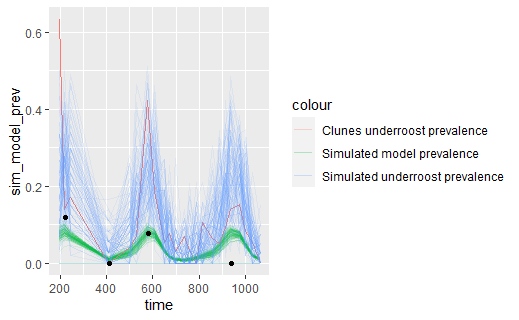

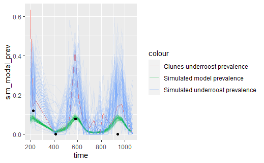

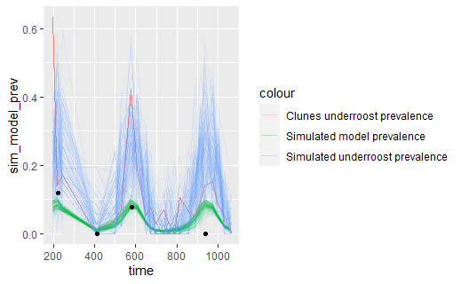

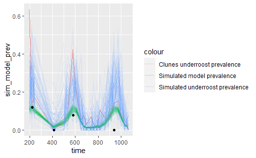

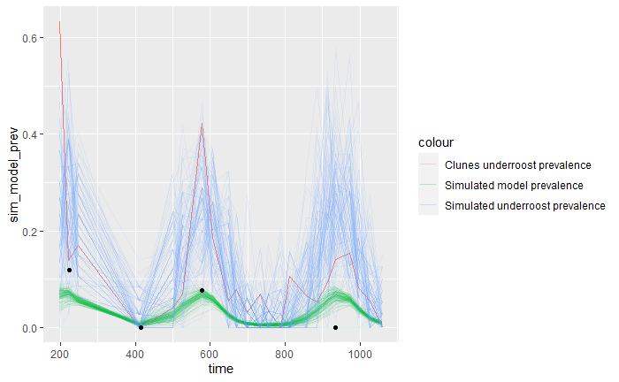

```r
for (i in 1:5){
    best_params_plots[[i]] +
     geom_point( aes(x = clu_catching$min_date, y = clu_catching$hen_prevalence)) -> plt
    plot(plt)
  }
```

### Keeping phi fixed - the following plots all have phi at 7.18

As Aaron and Olivier pointed out, phi (burth pulse timing) has a strong prior, so I took it out of the fitting, ad set it to 7.18 as most of Aaron’s posterior values were around that. I fitted again with it fixed, and got a bit better convergence. I have also realised phi is pi-periodic, so I will just keep it mod pi later.

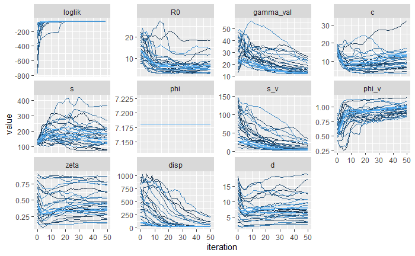

```r
 mf3iter2 %>%
  traces() %>%
  melt() %>%
  filter(variable %in% c("loglik", "R0", "gamma_val",  "zeta", "c",
                         "s", "phi","s_v", "phi_v", "disp", "d") )%>%
  ggplot(aes(x=iteration,y=value,group=L1,color=L1))+
  geom_line()+
  facet_wrap(~variable,scales="free_y")+
  guides(color=FALSE) -> pl1

plot(pl1)
```

```r
model6_likelihoods %>% select(-phi.mod.pi) %>% filter(phi == 7.181) -> model6_likelihoods_phi_fixed
head(model6_likelihoods_phi_fixed, 5) %>%
  select (c("loglik", "loglik.se", "R0", "gamma_val",  "zeta", "c",
                         "s", "phi","s_v", "phi_v", "disp", "d"))
```

|  | loglik | loglik.se | R0 | gamma_val | zeta | c | s | phi | s_v | phi_v | disp | d |
| --- | --- | --- | --- | --- | --- | --- | --- | --- | --- | --- | --- | --- |
| 1 | -57.54453 | 0.009968954 | 5.227942 | 11.87771 | 0.4640628 | 17.331683 | 121.0172 | 7.181 | 2.900758 | 1.087951 | 19.18561 | 5.637741 |
| 2 | -57.60813 | 0.005691381 | 11.599869 | 12.22953 | 0.3471573 | 9.547449 | 175.4662 | 7.181 | 3.505883 | 1.033714 | 19.43182 | 10.726261 |
| 3 | -57.67836 | 0.008660673 | 13.958071 | 12.38518 | 0.7306039 | 8.435841 | 180.6698 | 7.181 | 4.004995 | 1.027986 | 21.89052 | 5.005376 |
| 4 | -57.68949 | 0.005542066 | 6.421421 | 12.38594 | 0.3583930 | 15.122753 | 214.3643 | 7.181 | 4.159780 | 1.014977 | 19.84583 | 7.718574 |
| 5 | -57.69006 | 0.006567762 | 4.499066 | 12.53033 | 0.3757286 | 13.871835 | 114.5284 | 7.181 | 4.563461 | 1.000676 | 19.73751 | 6.414572 |

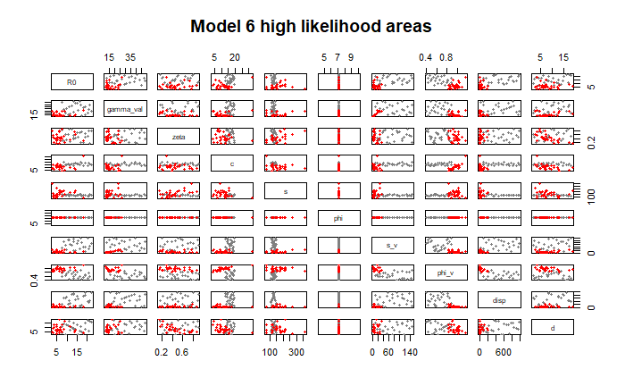

```r
  all <- ldply(list(guess=guesses,result=subset(model6_likelihoods_phi_fixed,loglik>max(loglik)-20)))
pairs(~R0+gamma_val+zeta+
        c+s+phi+s_v+phi_v+disp+d,data=all,col=ifelse(all$.id=="guess",grey(0.5),"red"),pch=20,main ="Model 6 high likelihood areas" )
```

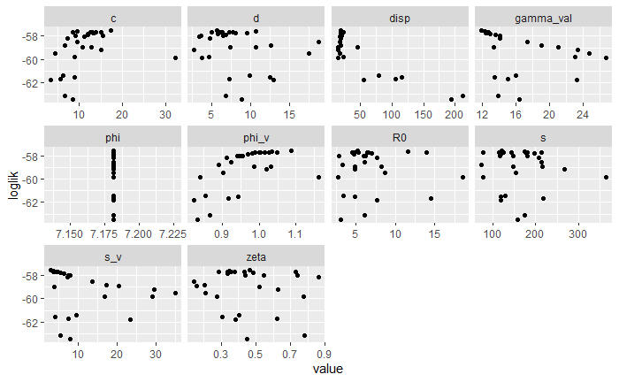

```r
gather(model6_likelihoods_phi_fixed, key, value, -loglik) %>%
  filter(key %in% c( "R0", "gamma_val",  "zeta", "c",
                              "s", "phi","s_v", "phi_v", "disp", "d")) %>%
ggplot(aes(value, loglik), main = "Results of model 6 IF") +
   geom_point() +
  facet_wrap(~ key , scales="free_x", ncol=4) -> pl4

plot(pl4)
```